# Correlation Exploration: Heatmaps, dendrograms and other fun things

Florencia Zúñiga

7/10/2019

In this portion of the analysis, we aim to better understand how our biomarkers relate to each other. Using heatmaps and dendograms we can see how cell lines from different tissues and genes cluster together and make predictions about how efficient the treatment of vorinostat might be when used to treat different kinds of cancer. Therefore, the goal of this document is to answer the following questions: Is there a connection between drug effectiveness and cell line? Are there specific types of cancer for which vorinostat can be used with more positive results?

# Table of contents

1. LOADING DATA

2. Visualization of the relationship between biomarkers and cell lines

- 2.1 Creation of tables with Biomarkers
- 2.2 Heatmaps)
  - 2.2.1. Heatmap with 30 Biomarkers and 59 cell lines
  - 2.2.2. Heatmap with 100 Biomarkers and 59 cell lines
- 2.3. Dendrogram
  - 2.3.1. A comparison of the clustering of biomarkers
  - 2.3.2. A comparison of the clustering of cell lines
  - 2.3.3. Comparison of dendrograms with 100 Biomarkers and 30 Biomarkers

## 1. LOADING DATA

### Loading packages

```r
library(readr)
library(rstudioapi)
library(BBmisc)

#Packages needed for the heatmap
library(pheatmap)
library("DESeq")
library(dendextend)

#Packages for the dendogram
library(ggplot2)
library(circlize)
library(tidyverse)
```

Reading the data

```r
# Reading the data
Untreated <- readRDS(paste0(wd,"/data/NCI_TPW_gep_untreated.rds"))
Treated <- readRDS(paste0(wd,"/data/NCI_TPW_gep_treated.rds"))

Metadata = read.table(paste0(wd,"/data/NCI_TPW_metadata.tsv"),
                      header = TRUE, sep ="\t", stringsAsFactors = TRUE)

Sensitivity <- readRDS(paste0(wd,"/data/NegLogGI50.rds"))


Basal <- readRDS(paste0(wd,"/data/CCLE_basalexpression.rds"))
Copynumber <- readRDS(paste0(wd,"/data/CCLE_copynumber.rds"))
Mutations <- readRDS(paste0(wd,"/data/CCLE_mutations.rds"))

Metadata = read.table(paste0(wd,"/data/NCI_TPW_metadata.tsv"), header = TRUE, sep ="\t", stringsAsFactors = TRUE)

Cellline_annotation = read.table(paste0(wd,"/data/cellline_annotation.tsv"),
                                 header = TRUE, sep ="\t", stringsAsFactors = TRUE)
Drug_annotation = read.table(paste0(wd,"/data/drug_annotation.tsv"),
                             header = TRUE, sep ="\t", stringsAsFactors = TRUE)

# Transforming the data

Treated <- as.data.frame(Treated)
Untreated <- as.data.frame(Untreated)
Sensitivity<- as.data.frame(Sensitivity)
```

Data normalization

```r
Untreated_norm <- apply(Untreated, 2, function(x){
  (x - mean(x)) / sd(x)
 })


Treated_norm <- apply(Treated, 2, function(x){
  (x - mean(x)) / sd(x)
 })


FC <- Treated - Untreated
FC_norm <- apply(FC, 2, function(x){
  (x - mean(x)) / sd(x)
 })
```

## 2. Visualization of the relationship between biomarkers and cell lines

### 2.1 Creation of tables with Biomarkers

To create these tables, the biomarkers found using the fold change in the first part of the specific analysis are used.

##### **Creation of a table for 30 biomarkers, with clean column and row names**

```r
# Table
cor1_tab = FC [ which(row.names(FC) %in% rownames(biomarkers_FC_values30)), ]

#Cleaning column and row names
col_names_cor1 = as.data.frame(strsplit(x=colnames(cor1_tab),split="_vorinostat"))
colnames (cor1_tab) = as.data.frame (t(col_names_cor1[1,]))[,1]

row_names_cor1 = as.data.frame(strsplit(x=rownames(cor1_tab),split="///HIST"))
rownames (cor1_tab) = as.data.frame (t(row_names_cor1[1,]))[,1]
```

```r
# Table
cor1.2_tab = FC [ which(row.names(FC) %in% rownames(biomarkers_FC_values100)), ]

#Cleaning column and row names
col_names_cor1.2    = as.data.frame(strsplit(x=colnames(cor1.2_tab),split="_vorinostat"))
colnames (cor1.2_tab) = as.data.frame (t(col_names_cor1.2[1,]))[,1]

row_names_cor1.2    = as.data.frame(strsplit(x=rownames(cor1.2_tab),split="///HIST"))
rownames (cor1.2_tab) = as.data.frame (t(row_names_cor1.2[1,]))[,1]
```

### 2.2 Heatmaps

#### 2.2.1 Heatmap with 30 Biomarkers and 59 cell lines

##### **Creation of a dataframe**

A data frame is needed for annotations that can be added to the heatmap and give us addtional information about the columns and the rows.

##### **Tissue Annotation**

First we create a table with the tissue that corresponds to each cell line and a function for the annotation. This is necessary, so that the heatmap can read it and then include the information.

```r
tissue <- Metadata[,-c(2:5)]

row.names(tissue) <- tissue$sample
tissue <- tissue[-c(1)]


tissue = as.data.frame(tissue)
cor1_tissue <- tissue[-c(1:1579), , drop=FALSE]
cor1_tissue = as.matrix(cor1_tissue)

row_names_cor1_t    = as.data.frame(strsplit(x=rownames(cor1_tissue),split="_vorinostat"))
colnames(cor1_tissue)[colnames(cor1_tissue)=="X786.0"] <- "786.0"
rownames (cor1_tissue) = as.data.frame (t(row_names_cor1_t[1,]))[,1]

names(cor1_tissue)[names(cor1_tissue)=="V1"] <- "Tissue"
```

#### **Heatmap**

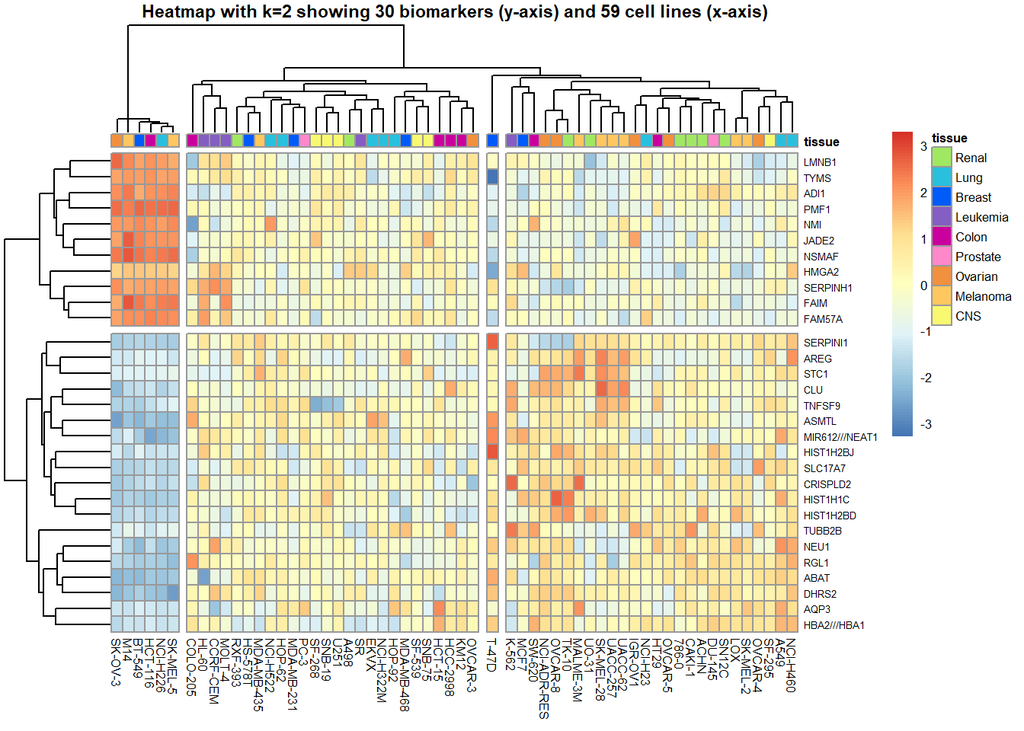

```r
# Setting colors that are good visivility
cor1_colour = list(tissue = c("Renal" = "#A0E862",
                       "Lung" = "#29C0DE",
                       "Breast" = "#005BF8",
                       "Leukemia" = "#845EC2",
                       "Colon" = "#CA009E",
                       "Prostate" = "#FF88CB",
                       "Ovarian" = "#F1903D",
                       "Melanoma" = "#FFC75F",
                       "CNS" = "#F9F871"
                       )
                   )

# Heatmap with annotations and breaks
cor1 = pheatmap(cor1_tab,
                annotation_colors = cor1_colour,
                annotation_col = cor1_tissue,
                fontsize = 6.5,
                fontsize_row= 5,
                fontsize_col = 6,
                gaps_col=50,
                info = TRUE,
                cutree_rows = 2,
                cutree_cols = 4,
                main = "Heatmap with k=2 showing 30 biomarkers (y-axis) and 59 cell lines (x-axis)",
                scale = "row"
                )
```

There is a cluster of cell lines with relative leves of expression that are considerably high and low. This cluster includes 2 melanoma cells, one ovarian cell, one breast cell, one colon cell and one lung cell. Genes cluster here in two groups: high and low expression.

Perhaps the most eye-catching characteristic is that when using breaks to better visualize the heatmap, one cell line appears that behaves in such a way that it separates it from all other cell lines. Further reading does not clarify the behaviour of the cell line **T-47D**, which is why this cancer cell is probably just an outlier. This result highlights the importance of choosing the appropiate cell line when conduction research. The genome of a cell line defines its behaviour and we must be aware of it to decide if using it will render insightful results.

Another interesting thing is that several, but not all, melanoma and leukemia cells are very up-regulated in comparison to cells of other tissues. Nevertheless, as this observation can only be made for some melanoma and some leukemia cells, it is not enough to say that vorinostat has a higher impact on those types of cancer cells. If anything, what we can conlcude is that vorinostat does not appear to affect any tipe of cell belonging to a particular tissue in a specific way. This is surprising and gives rise to some questions. If this drug is not tissue specific, why is it used mostly for akute myeloid leukemia? If it does not affect the level of expression, through which mechanism does it help treat cancer?

#### 2.2.2 Heatmap with 100 Biomarkers and 59 cell lines

##### **Annotations**

Here we can use the same annotation functions as in Heatmap with 30 Biomarkers and 59 cell lines: cor1_tissue and cor1_colour.

#### **Heatmap for 100 Biomarkers**

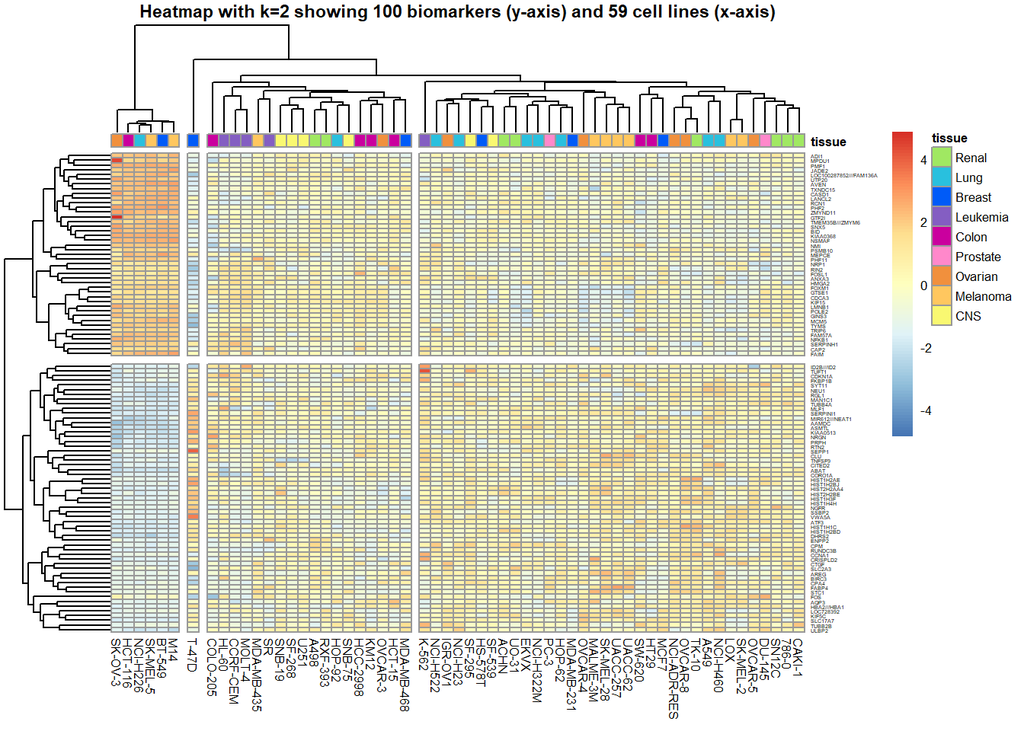

With this heatmap we can see how the relationshiop between cell lines and genes changes when we consider more data. Now on the very left of the heatmap we can see once again a heatmap of cell lines with genes that are very up or very down regulated. In the previous heatmap, when we considered only 30 biomarkers, 2 melanoma cells, one ovarian cell, one breast cell, one colon cell and one lung cell belonged to that cluster with very high/low expression. Now that we take 100 biomarkers into account the same cell lines are clustered in this group, but how they are clustered within their group has changed.

*T-47D* continues to appear separated from the rest.

Some melanoma and leukemia cells seem to still show considerably high regulation for some biomarkers in comparison to other cell lines.

Just as in the previous heatmap, cell lines belonging to the same tissue form small gruops showing similar behaviour, but these groups are not formed for all the cell lines belonging to one tissue. Therefore, we can conclude that using vorinostat on different cell lines belonging to one tissue will not show specific nor equal results, and that with our results there are no types of cancer that are better suited for the treatment with vorinostat.

### 2.3 Dendrogram

Plotting the heatmaps using different amounts of biomarkers makes it clear that the relationship between these genes changes as more biomarkers are considered. Here we aim to explore those changes and consider the impact they might have.

#### 2.3.1 A comparison of the clustering of biomarkers

##### **Recreation of the hierachichal clustering of both heatmaps**

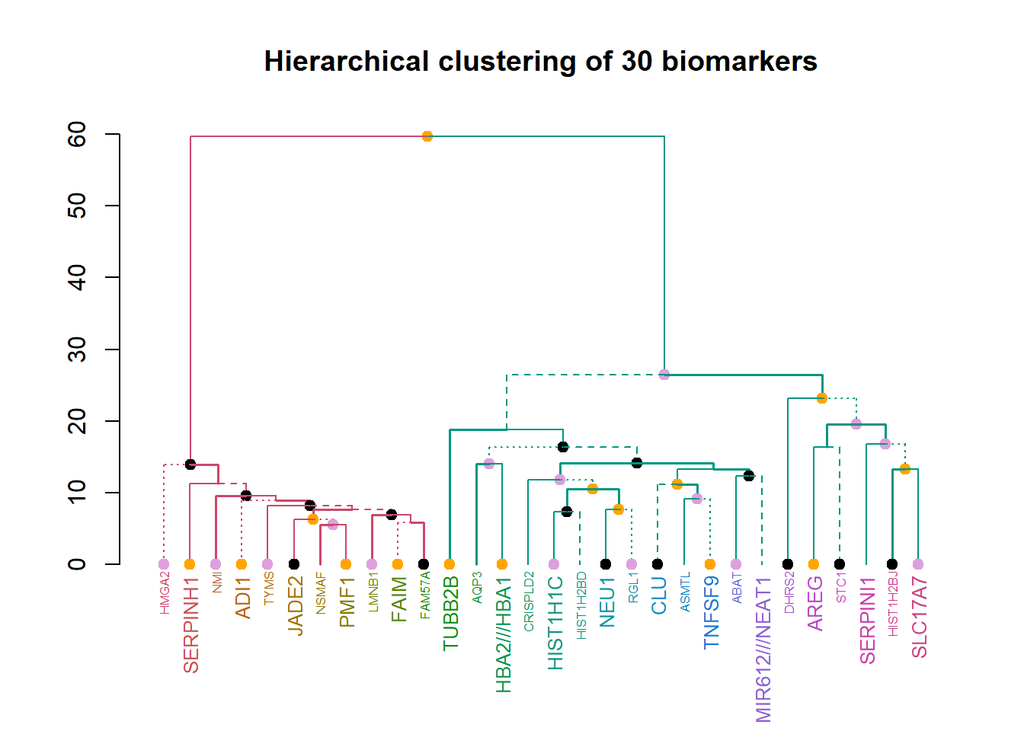

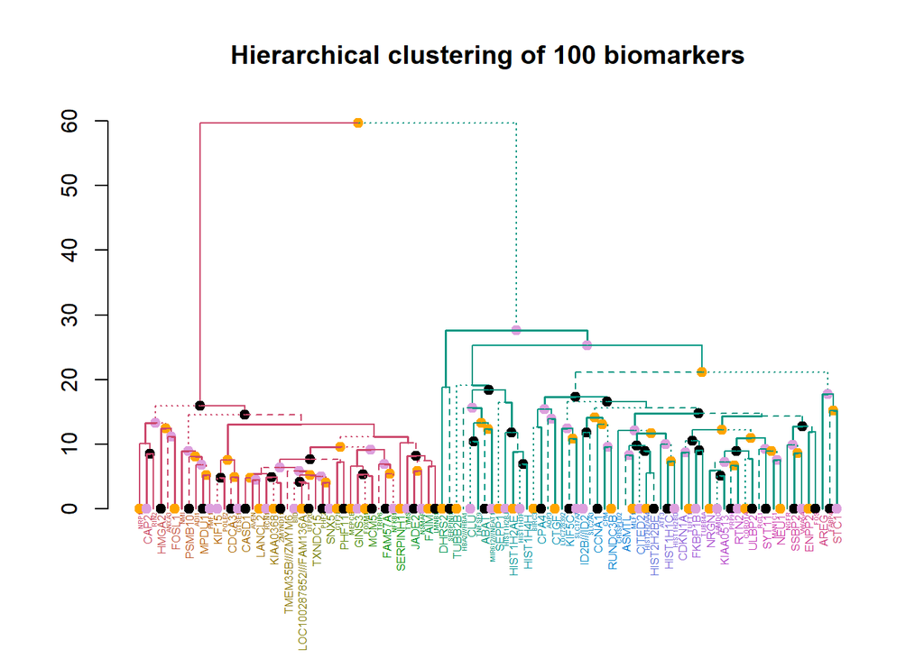

```r
# Dedrogram for 30 biomarkers
d_gg30 <- cor1_tab %>% dist %>% hclust %>% as.dendrogram %>%
  set("branches_k_color", k=2) %>% set("branches_lwd", c(1.5,1,1)) %>%
  set("branches_lty", c(1,1,3,1,1,2)) %>%
  set("labels_colors") %>% set("labels_cex", c(.5,0.8)) %>%
  set("nodes_pch", 19) %>% set("nodes_col", c("orange", "black", "plum", NA),
                               )

plot(d_gg30,
     main = "Hierarchical clustering of 30 biomarkers")
```

To which cluster do some of our genes belong, when we consider only 30 biomarkers?

```r
head(d_gg30_t, n=10)
```

```
##     ABAT     ADI1     AQP3     AREG    ASMTL      CLU CRISPLD2    DHRS2
##        1        2        1        1        1        1        1        1
##     FAIM   FAM57A
##        2        2
```

We can see that different genes belong to one of two different clusters.

To which cluster do some of our genes belong, when we consider 100 biomarkers?

```r
head(d_gg100_t, n=10)
```

```
## AAMDC  ABAT  ADI1 ANXA3  AQP3  AREG ASMTL  ATF3  AVEN   BID
##     1     1     2     2     1     1     1     1     2     2
```

#### 2.3.2 A comparison of the clustering of cell lines

##### **Recreation of the hierachichal clustering of both heatmaps**

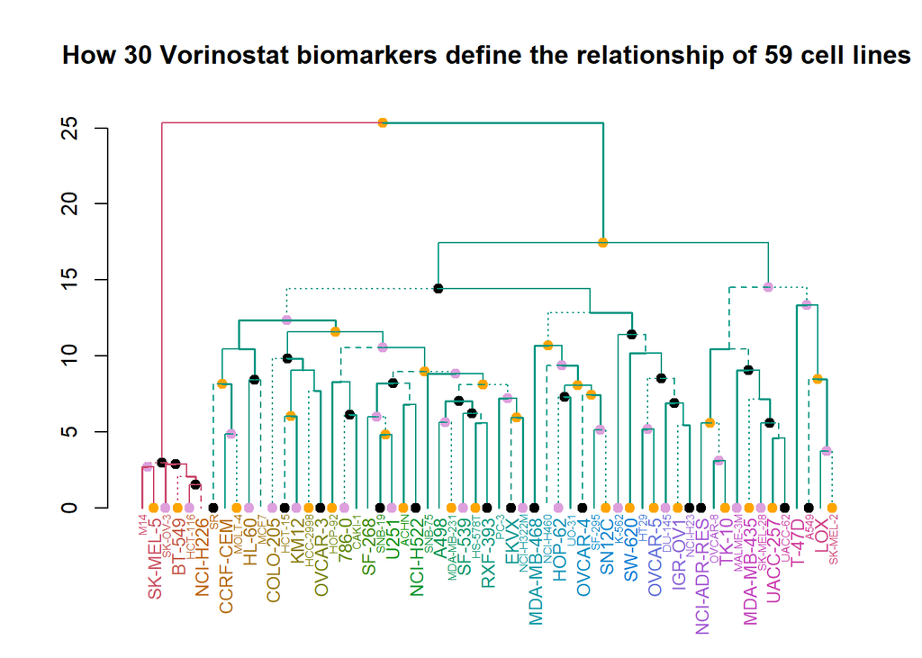

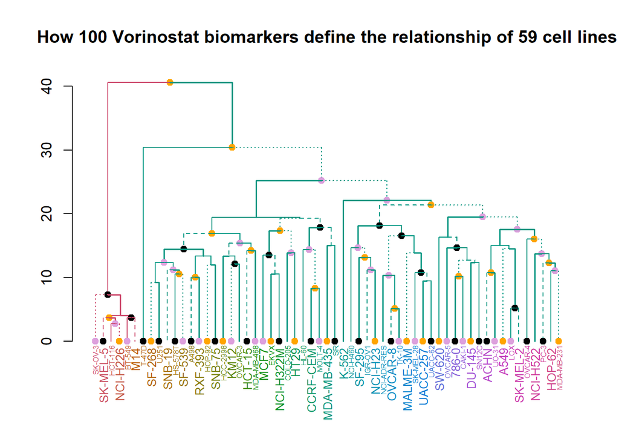

```r
# Dedrogram for 59 cell lines with 30 biomarkers
d_gg30t <- t(cor1_tab) %>% dist %>% hclust %>% as.dendrogram %>%
  set("branches_k_color", k=2) %>% set("branches_lwd", c(1.5,1,1)) %>%
  set("branches_lty", c(1,1,3,1,1,2)) %>%
  set("labels_colors") %>% set("labels_cex", c(.5,0.8)) %>%
  set("nodes_pch", 19) %>% set("nodes_col", c("orange", "black", "plum", NA)
  )

plot(d_gg30t,
      main = "How 30 Vorinostat biomarkers define the relationship of 59 cell lines")
```

#### 2.3.3 Comparison of dendrograms with 100 Biomarkers and 30 Biomarkers

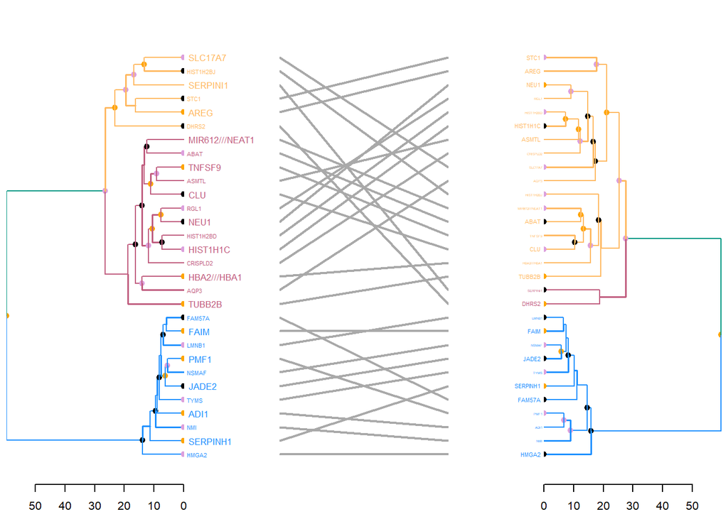

```r
#Creating a dendlist
dl_BM <- dendlist(
  d_gg30 %>%
    set("labels_col", value = c("#1E90FF", "#c05c7e", "#ffb961"), k=3) %>%
    set("branches_lty", 1) %>%
    set("branches_k_color", value = c("#1E90FF", "#c05c7e", "#ffb961"), k = 3),
  d_gg100 %>%
    set("labels_col", value = c("#1E90FF", "#c05c7e", "#ffb961"), k=3) %>%
    set("branches_lty", 1) %>%
    set("branches_k_color", value = c("#1E90FF", "#c05c7e", "#ffb961"), k = 3)
                  )

#Plot both dendograms for comparison
tanglegram(dl_BM,
           common_subtrees_color_lines = FALSE,
           highlight_distinct_edges  = TRUE,
           highlight_branches_lwd=FALSE,
           margin_inner=7,
           lwd=2
           )
```

The trees were pruned because the labels in both dendrograms had different values.

The dendrogram on the left corresponds to that of the 30 biomarkers and the one on the right to that of 100 biomarkers. Here we can see increasing the number of biomarkers drasticaclly changes the relationships that arise in our data.

This rises some questions about research in general, and how relatively small changes can alter the results of a study completely. When we choose how many genes should be considered biomarkers, we can take the p-value into consideration, but as it could be seen with the t-test, many genes could be biomarkers because many had low p-values. So, in cases like that one, where do we draw the line? And when our results can drastically change we we consider some more biomarkers, how do we know we are choosing the exact right number? The answer to such questions is beyond our interest for this exploration. However, these questions remain relevant and should be kept in mind.

**The goal of this document was to answer the following questions: Is there a connection between the drug effectiveness and cell line? Are there specific types of cancer for which vorinostat can be used with more positive results?** Relying on the results of the heatmap, we can conclude that there is no significant connection between the drug effectiveness and cell line, and that vorinostat does not appear to affect one or some types of cancer in a particular way in a consistent manner.However, it should be pointed that some interesting results were rendered. For eample, groups of 3-4 cell lines belonging to one type of tissue form small goups with similar behaviour. Another interesting result is that many melanoma and leukemia cells have biomarkers with a higher expression than most cell lines belonging to other tissues.